# sEEG data preprocessing pipeline

Contributor: Hao Zhu (haozhu@cuhk.edu.hk)

Create Date: 2024/10/02

This tutorial is based on:

- Ubuntu 24.04.1 LTS 64-bit
- Python 3.12.4
  - mne 1.8.0
  - re 2.2.1
  - h5py 3.11.0
  - numpy 1.26.4
  - seaborn 0.13.2
  - matplotlib 3.8.4
  - scipy 1.13.1
  - pingouin 0.5.5

# Introduction

This tutorial focuses on processing stereotactic EEG (sEEG) data using Python. We'll cover several key stages, including data loading, preprocessing, feature extraction, and visualization, using popular libraries such as MNE, NumPy, and scipy.

Different labs use different pipelines and methods to do preprocessing. This pipeline combines multiple pipelines from other labs and is tested to be a good fit for sEEG data collected from Shenzhen and Guangzhou.

In this tutorial, I use a sample dataset from a real subject (sz04) collected from Shenzhen Second People's Hospital.

The raw data collected from the hospital's Nicolet acquisition machine is in EDF format. It is cut, the bad channel was dropped, and transformed to FIF format with MNE-python. The event is recorded in the "TRIG" channel, and pulses with different magnitudes represent different events (e.g., a high magnitude pulse normally means PC sent marker). Extract events from the "TRIG" channel and store it in .eve format (check the example .eve to get a sense of the event format: [timestamp, 0, event_id]).

Two files are required for this tutorial:

- event file ending in .eve
- Cut raw data file ending in .fif

# Loading modules

```python
import mne, re, h5py
import numpy as np
import seaborn as sns
import matplotlib.pyplot as plt
import scipy.signal as signal
from scipy.stats import sem
from tqdm import tqdm
import pandas as pd
import pingouin as pg
```

## file pathways

```python
data_path = '/home/haozhu/brainstormdb/Test_data/'
img_path = '/home/haozhu/brainstormdb/Test_data/Figures/'
subject_id = 'sz04'

fs_subject = 'fsaverage'
fs_path = '/home/haozhu/freesurfer/subjects/'
```

# pre-processing

## load and drop epileptic contacts

```python
subject_Datadir = f'{data_path}/{subject_id}_2022_09_17_rawMP_s1_'
eventFile_name = f'{subject_Datadir}events.eve'
rawMPFile_name = f'{subject_Datadir}ieeg.fif'
epochFile_name = f'{subject_Datadir}epoch-epo.fif'
```

```python
epileptic_contacts = ['A1', 'A2', 'A3', 'A4', 'A5',
                      'H1', 'H2', 'H3', 'H4', 'H5']
#The epileptic contacts that were determined by neuroelectrophysiologist
```

We begin by loading the raw sEEG data and event file using MNE.

And drop the pre-determined epileptic contacts

```python
raw = mne.io.read_raw_fif(rawMPFile_name, preload=True)

events = mne.read_events(eventFile_name)

raw.drop_channels(['TRIG'])
#drop "TRIG" channel as it's no longer needed. Events should already be extracted before starting preprocessing.

raw.drop_channels(epileptic_contacts)
```

```
Opening raw data file /home/haozhu/brainstormdb/Test_data//sz04_2022_09_17_rawMP_s1_ieeg.fif...
Isotrak not found
    Range : 458000 ... 994000 =    458.000 ...   994.000 secs
Ready.
Reading 0 ... 536000  =      0.000 ...   536.000 secs...
```

|  | **General** |  |
| --- | --- | --- |
|  | Filename(s) | sz04_2022_09_17_rawMP_s1_ieeg.fif |
|  | MNE object type | Raw |
|  | Measurement date | 2022-09-17 at 10:57:27 UTC |
|  | Participant | Unknown |
|  | Experimenter | Unknown |
|  | **Acquisition** |  |
|  | Duration | 00:08:56 (HH:MM:SS) |
|  | Sampling frequency | 1000.00 Hz |
|  | Time points | 536,001 |
|  | **Channels** |  |
|  | EEG |  |
|  | Head & sensor digitization | Not available |
|  | **Filters** |  |
|  | Highpass | 0.00 Hz |
|  | Lowpass | 500.00 Hz |

## filters

sEEG data often contains powerline noise (e.g., 50 Hz). We apply a notch filter to remove this noise.

We further apply a band-pass filter to focus on frequencies of interest., which is commonly less than 200hz

```python
raw.notch_filter([50,100,150,200])

raw.filter(l_freq=0.1, h_freq=200)
```

```
Filtering raw data in 1 contiguous segment
Setting up band-stop filter

FIR filter parameters
---------------------
Designing a one-pass, zero-phase, non-causal bandstop filter:
- Windowed time-domain design (firwin) method
- Hamming window with 0.0194 passband ripple and 53 dB stopband attenuation
- Lower transition bandwidth: 0.50 Hz
- Upper transition bandwidth: 0.50 Hz
- Filter length: 6601 samples (6.601 s)
```

```
[Parallel(n_jobs=1)]: Done  17 tasks      | elapsed:    0.1s
[Parallel(n_jobs=1)]: Done  71 tasks      | elapsed:    0.5s
[Parallel(n_jobs=1)]: Done 161 tasks      | elapsed:    1.1s
```

```
Filtering raw data in 1 contiguous segment
Setting up band-pass filter from 0.1 - 2e+02 Hz

FIR filter parameters
---------------------
Designing a one-pass, zero-phase, non-causal bandpass filter:
- Windowed time-domain design (firwin) method
- Hamming window with 0.0194 passband ripple and 53 dB stopband attenuation
- Lower passband edge: 0.10
- Lower transition bandwidth: 0.10 Hz (-6 dB cutoff frequency: 0.05 Hz)
- Upper passband edge: 200.00 Hz
- Upper transition bandwidth: 50.00 Hz (-6 dB cutoff frequency: 225.00 Hz)
- Filter length: 33001 samples (33.001 s)
```

```
[Parallel(n_jobs=1)]: Done  17 tasks      | elapsed:    0.2s
[Parallel(n_jobs=1)]: Done  71 tasks      | elapsed:    0.8s
[Parallel(n_jobs=1)]: Done 161 tasks      | elapsed:    1.7s
```

|  | **General** |  |
| --- | --- | --- |
|  | Filename(s) | sz04_2022_09_17_rawMP_s1_ieeg.fif |
|  | MNE object type | Raw |
|  | Measurement date | 2022-09-17 at 10:57:27 UTC |
|  | Participant | Unknown |
|  | Experimenter | Unknown |
|  | **Acquisition** |  |
|  | Duration | 00:08:56 (HH:MM:SS) |
|  | Sampling frequency | 1000.00 Hz |
|  | Time points | 536,001 |
|  | **Channels** |  |
|  | EEG |  |
|  | Head & sensor digitization | Not available |
|  | **Filters** |  |
|  | Highpass | 0.10 Hz |
|  | Lowpass | 200.00 Hz |

## re-reference with ESR

The primary purpose of re-referencing is to mitigate the impact of the reference electrode on the recorded sEEG signals. In this sample dataset, sEEG signals were online referenced with contact (1 or 2) in the white matter (monopolar method). This reference electrode can pick up artifacts that affect all other channels, potentially distorting the true brain signals of interest. And it reduces biases introduced by the original reference electrode and minimizes spurious correlations between channels.

It can help improve the overall signal quality and signal-to-noise ratio (SNR). By choosing an appropriate re-referencing method, researchers can reduce common noise and artifacts that may be present in the original reference. You may refer to this paper for more comprehensive info about which method to use: https://pmc.ncbi.nlm.nih.gov/articles/PMC6495648/

I selected Electrode Shaft Reference (ESR: re-referenced each channel to the average signal of all channels on the same shaft) for the dataset collected from Shenzhen after scrutinizing all possible methods.

```python
def find_electrode_indices(contacts):
    '''
    This function loops through all contacts and returns the indices where each electrode shaft starts and ends.
    '''
    electrode_indices = {}
    current_electrode = None
    start_index = 0

    # Regex to extract the prefix (non-digit characters) from each contact
    prefix_pattern = re.compile(r"^[A-Z]+'?")

    for i, contact in enumerate(contacts):
        # Extract the prefix using regex
        match = prefix_pattern.match(contact)
        if match:
            prefix = match.group()
            if prefix != current_electrode:
                # If it's not the first electrode, save the previous electrode's indices
                if current_electrode is not None:
                    electrode_indices[current_electrode] = (start_index, i - 1)
                # Update current electrode and start index
                current_electrode = prefix
                start_index = i

    # Add the last electrode's indices
    if current_electrode is not None:
        electrode_indices[current_electrode] = (start_index, len(contacts) - 1)

    return electrode_indices

contacts = raw.info['ch_names']
electrode_indices = find_electrode_indices(contacts)
electrode_indices
```

```
{'A': (0, 9),
 'H': (10, 19),
 'J': (20, 37),
 'OB': (38, 52),
 'V': (53, 62),
 'X': (63, 77),
 'Z': (78, 92),
 'O': (93, 102),
 'Y': (103, 118),
 'E': (119, 130),
 'F': (131, 142),
 'W': (143, 154),
 'M': (155, 170),
 "X'": (171, 184),
 "Y'": (185, 200)}
```

```python
'''
Iterate over each electrode and compute the average signal,
which is then subtracted from the original signal.
'''
raw_data = raw.copy().get_data()

electrode_shaft_average = np.zeros(raw_data.shape)

for electrode in electrode_indices.keys():

    electrode_start, electrode_end = electrode_indices[electrode]
    esr = np.mean(raw_data[electrode_start:electrode_end+1],axis=0)
    electrode_shaft_average[electrode_start:electrode_end+1] = esr

raw._data = raw_data - electrode_shaft_average
```

## epoching

event_id 4: passive listening audio trigger

The length of the epoch is determined based on the task design and follow-up analysis, e.g., for time-frequency analysis, to avoid **edge effect**, the epoch should be at least 3-5 cycles longer than the lowest frequency of interest.

Baseline correction normally should be set to "True". Here, it is set to "None" due to my specific task design.

Detrend is recommended, as it removes drift over a long period of time.

```python
epoch = mne.Epochs(raw, events,tmin=-2.0, tmax=2.0, baseline=None,detrend=1,
					reject=None, preload=True)
```

```
Not setting metadata
271 matching events found
No baseline correction applied
0 projection items activated
Using data from preloaded Raw for 271 events and 4001 original time points ...
```

```
0 bad epochs dropped
```

## drop improbable epoch

```python
epoch_data = epoch.get_data(copy=True)
contact_number = epoch_data.shape[1]
epoch_data_mean = epoch_data.mean(axis=0)
epoch_data_sd = epoch_data.std(axis=0)

epoch_thredhold = 350e-4
epoch_peak_value = np.abs(epoch_data).max(axis=2)

for ind,each_epoch in enumerate(epoch_peak_value):
    improbable_contacts_ratio = len(set(np.where(each_epoch > epoch_thredhold)[0])) / contact_number
    if improbable_contacts_ratio > 0.5:
        print("peak",ind,improbable_contacts_ratio)

for ind,each_epoch in enumerate(epoch_data):
    improbable_contacts_ratio = len(set(np.where(each_epoch > epoch_data_mean + 4*epoch_data_sd)[0])) / contact_number
    if improbable_contacts_ratio > 0.5:
        print('sd',ind,improbable_contacts_ratio)
```

```python
# unmute only when above output isn't blank
# improbable_epoch = []
# epoch.drop(improbable_epoch)
```

## save to epoch file

```python
epoch.save(epochFile_name)
```

# Active contact selection

Not all contacts are responsive to auditory stimuli. Therefore, we need an objective measurement to select those that are responsive.

## load epoch

```python
epochFile_name = f'{subject_Datadir}epoch-epo.fif'
```

```python
epoch = mne.read_epochs(epochFile_name)
```

```
Reading /home/haozhu/brainstormdb/Test_data/sz04_2022_09_17_rawMP_s1_epoch-epo.fif ...
Isotrak not found
    Found the data of interest:
        t =   -2000.00 ...    2000.00 ms
        0 CTF compensation matrices available
```

```
Not setting metadata
271 matching events found
No baseline correction applied
0 projection items activated
```

## filter high gamma response

The target signal of interest is called the high gamma band, which is 70-150 Hz. It’s been used for the past decades as a local index of cortical activity, and it correlates with underlying spiking activity as well as the underlying BOLD activity. It is extremely robust across trials, so we extract epochs in the high gamma band.

```python
epoch_high_gamma = epoch.copy().filter(70,150)
epoch_data = epoch_high_gamma["4"].get_data(copy=True)
```

```
Setting up band-pass filter from 70 - 1.5e+02 Hz

FIR filter parameters
---------------------
Designing a one-pass, zero-phase, non-causal bandpass filter:
- Windowed time-domain design (firwin) method
- Hamming window with 0.0194 passband ripple and 53 dB stopband attenuation
- Lower passband edge: 70.00
- Lower transition bandwidth: 17.50 Hz (-6 dB cutoff frequency: 61.25 Hz)
- Upper passband edge: 150.00 Hz
- Upper transition bandwidth: 37.50 Hz (-6 dB cutoff frequency: 168.75 Hz)
- Filter length: 189 samples (0.189 s)
```

[output not shown]

## calculate hg power of passive listening

```python
def get_baseline_timelag(epoch_object):

    #specific to my task design, do NOT take this as standard procedure.
    #Normally, the baseline is set to ~200ms before stimulus onset.

    baseline_timelag = {4:[],7:[],11:[],2:[],8:[],12:[]}

    epoch_event = epoch_object.events

    for c_index in tqdm(baseline_timelag.keys()):

        if c_index in [2,4]:
            minus_number = 1
        elif c_index in [7,11,8,12]:
            minus_number = 2

        for event in epoch_object[f'{c_index}'].events:
            e_abs_index = np.where(epoch_event[:,0]==event[0])[0]
            e_visual = epoch_object.events[e_abs_index-minus_number][0]
            time_lag = (e_visual[0] - event[0]) / 1000
            baseline_timelag[c_index].append(time_lag)

    return baseline_timelag

baseline_timelag = get_baseline_timelag(epoch)
```

the envelope of the filtered signal was derived using a Hilbert transform. This transformed signal was then logged, normalized using a z-score, smoothed, exponentiated, and recentered to zero (by subtracting 1).

```python
def calculate_broadband_power(epochs_data):
    fs = 1000
    n_epochs, n_channels, n_time = epochs_data.shape
    broadband_power = np.zeros_like(epochs_data)
    baseline_power = np.zeros((n_epochs, n_channels, 200))

    for i in tqdm(range(n_epochs)):
        for j in range(n_channels):
            power_series = np.zeros(n_time)

            # hilbert transform to get analytic power
            analytic_signal = signal.hilbert(epochs_data[i, j])
            power = np.abs(analytic_signal)**2
            power_series += power

            # Log transformation
            power_series = np.log(power_series + 1e-20)

            # Z-scoring to baseline -250ms to -50ms before visual onset
            baseline_onset = int(baseline_timelag[4][i] * fs) + 2000
            baseline_data = power_series[baseline_onset-250:baseline_onset-50]
            baseline_mean = np.mean(baseline_data)
            baseline_std = np.std(baseline_data)
            power_series = (power_series - baseline_mean) / baseline_std

            # Smoothing - simple moving average
            window_size = int(fs * 0.15)  # 0.15 second window
            power_series = np.convolve(power_series, np.ones(window_size)/window_size, mode='same')

            # Exponentiation
            power_series = np.exp(power_series)

            # Centering at zero (subtract 1)
            broadband_power[i, j] = power_series - 1
            baseline_power[i, j] = power_series[baseline_onset-250:baseline_onset-50] - 1

    return broadband_power, baseline_power

hg_power, hg_pre_response = calculate_broadband_power(epoch_data)
```

Visualization of the z-scored, average across epoch, channel data. each trace represent a contact.

X-axis: 0 denotes stimulus onset, scale in ms.

Y-aixs: z-score

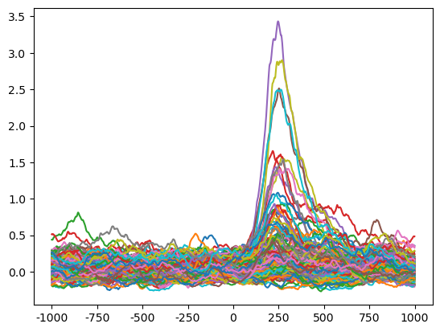

```python
for n in range(epoch_data.shape[1]):
    plt.plot(hg_power.mean(axis=0)[n][1000:3000])
plt.xticks(ticks=np.arange(0,2001,250),labels=np.arange(0,2001,250)-1000)
plt.show()
```

## select active contact with t test

In the passive listening task, contacts demonstrated a significant enhancement in response (p < 0.01, paired t-test, Bonferroni corrected) from the onset of the auditory probe (0 to 0.5 seconds) compared to a baseline period (−250 to −50 ms before the visual cue onset) were selected.

Additionally, you can choose the criteria of a high signal-to-noise atio (z > 1.3) during post-stimulus period as selection criteria.

```python
def calculate_response_windows(data, fs, onsets):
    post_start = onsets + int(0 * fs)
    post_end = onsets + int(0.5 * fs)

    # Averaging response across all epochs for each channel
    post_responses = data[:, :, post_start:post_end].mean(axis=2)

    return post_responses

def perform_paired_t_test(pre_responses, post_responses, alpha=0.01):
    n_channels = pre_responses.shape[1]
    results = pd.DataFrame(index=range(n_channels), columns=['T', 'p-val', 'p-corrected', 'significant'])

    for channel in range(n_channels):
        # Perform paired t-tests for each channel
        res = pg.ttest(pre_responses[:,channel], post_responses[:,channel], paired=True)
        results.loc[channel, 'T'] = res['T'].values[0]
        results.loc[channel, 'p-val'] = res['p-val'].values[0]

    # Bonferroni correction
    results['p-corrected'] = results['p-val'].astype(float) * n_channels
    results['p-corrected'] = results['p-corrected'].apply(lambda x: min(x, 1))  # Corrected p-values capped at 1
    results['significant'] = results['p-corrected'] < alpha

    return results

post_responses = calculate_response_windows(hg_power, 1000, 2000)
pre_responses = hg_pre_response.mean(axis=2)
test_results = perform_paired_t_test(pre_responses, post_responses)
```

```python
active_index = np.where(test_results['significant'] == True)[0]
```

```python
for ind in active_index:
    print(epoch.ch_names[ind])
```

```
Z11
E5
W2
M8
M9
M10
M11
M12
M14
M15
```

Visually check every selected contact, its waveform over time, and distribution over trials (check whether some outlier trials cause it to be significant).

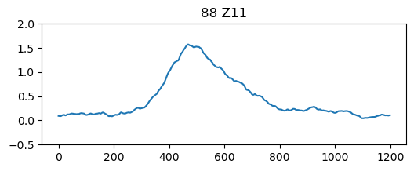

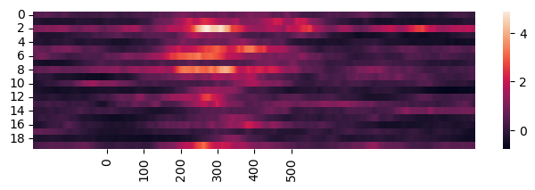

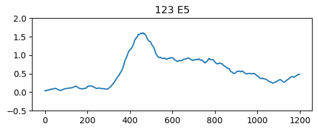

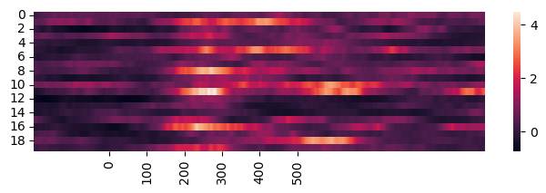

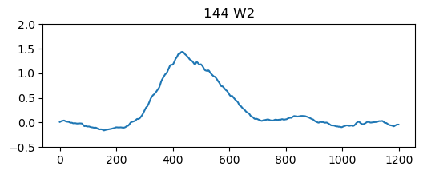

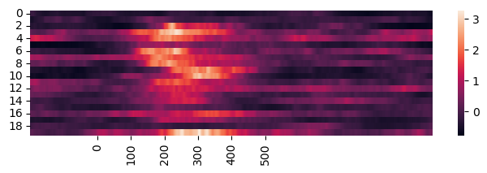

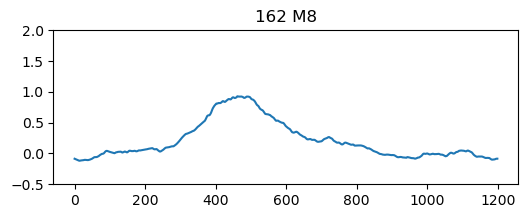

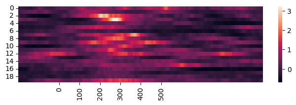

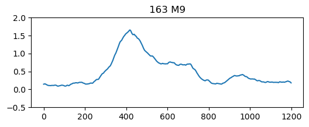

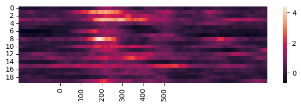

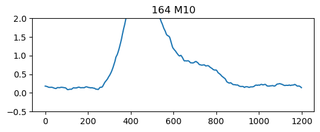

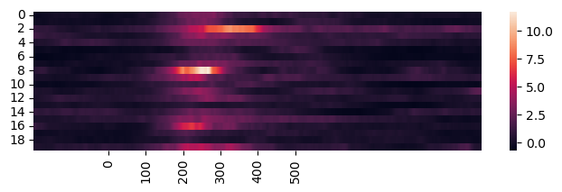

[8 more figures not shown]

```python
for n in active_index:
    plt.figure(figsize=(6,2))
    plt.plot(hg_power.mean(axis=0)[n][1800:3000])
    plt.title(f'{n} {epoch.ch_names[n]}')
    plt.ylim(-.5,2)
    plt.show()

    plt.figure(figsize=(8,2))
    ax = sns.heatmap(hg_power[:,n,1800:3000])
    ax.set_xticks([200,300,400,500,600,700],labels=[0,100,200,300,400,500])
    plt.show()
```

```python
selected_active_contacts = ["Z11","E5","W2","M8","M9","M10","M11","M12","M14","M15"]
selected_active_contacts_index = [m for m,n in enumerate(epoch.ch_names) if n in selected_active_contacts]
selected_active_contacts_index
```

```
[88, 123, 144, 162, 163, 164, 165, 166, 168, 169]
```

## plot active contacts within all channels

```
(29, 7)
```

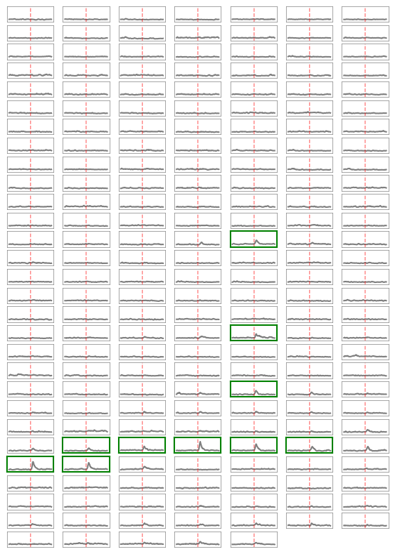

```python
def plot_channels(data):
    """
    Plot each channel on a separate subplot within a single figure.

    Parameters:
    - data: numpy array of shape [n_channels, n_times]
    """
    n_channels, n_times = data.shape

    col = 7
    row = n_channels // col + 1

    fig, axs = plt.subplots(row, col, figsize=(7, 10))
    print(axs.shape)
    for i in range(axs.shape[0]):
        for j in range(axs.shape[1]):
            plot_number = i*col+j
            ax = axs[i,j]
            ax.axis('off')
            if plot_number < data.shape[0]:
                ax.plot(data[plot_number], color='k', alpha=0.5)
                ax.plot([2000,2000],[-1,5],color='red',
                        alpha=0.5,linestyle='--',linewidth=1)
                ax.set_ylim(-1,5)
                ax.axis('on')

                for spine in ax.spines.values():
                    spine.set_edgecolor('grey')
                    spine.set_linewidth(0.5)

                if plot_number in selected_active_contacts_index:
                    for spine in ax.spines.values():
                        spine.set_edgecolor('green')
                        spine.set_linewidth(1.5)

            ax.set_xticks(ticks=[])
            ax.set_yticks(ticks=[])

    # plt.tight_layout()
    plt.show()
    return fig

# Example usage:
hg_power_mean = np.mean(hg_power,axis=0)
all_channel_figure = plot_channels(hg_power_mean)
```

```python
all_channel_figure.savefig(f"{img_path}{subject_id}_all_channels.png",dpi=300)
```

## plot active contacts

```
(4, 3)
```

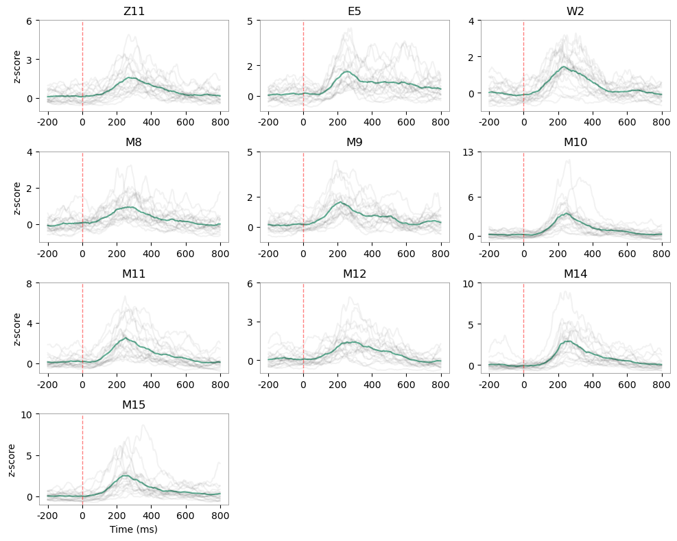

```python
def plot_active_channels(data):
    """
    Plot each channel on a separate subplot within a single figure.

    Parameters:
    - data: numpy array of shape [n_channels, n_times]
    """
    n_channels = len(selected_active_contacts_index)
    n_times = data.shape[1]

    plot_start, plot_end = 1800, 2800 #-200ms to 800ms

    col = 3
    row = n_channels // col + 1

    fig, axs = plt.subplots(row, col, figsize=(10, 8))
    print(axs.shape)
    for i in range(axs.shape[0]):
        for j in range(axs.shape[1]):
            plot_number = i*col+j
            ax = axs[i,j]
            ax.axis('off')
            if plot_number < n_channels:
                ax.axis('on')
                ax.set_xticks(ticks=[])
                if j == 0:
                    ax.set_ylabel('z-score')

                ax.set_xticks(ticks=np.arange(0,1001,200),labels=np.arange(0,1001,200)-200)

                if i == row - 1:
                    ax.set_xlabel('Time (ms)')

                channel_index = selected_active_contacts_index[plot_number]
                ax.plot(data.mean(axis=0)[channel_index,plot_start:plot_end],
                        color='#62B197', alpha=1)

                for e in data:
                    ax.plot(e[channel_index,plot_start:plot_end],color='k',alpha=0.05)

                y_max = np.round(data[:,channel_index,plot_start:plot_end].max()) + 1
                ax.set_yticks(ticks=[0,y_max//2,y_max])
                ax.plot([200,200],[-1,y_max],color='red',
                        alpha=0.5,linestyle='--',linewidth=1)

                ax.set_ylim(-1,y_max)
                ax.set_title(f"{epoch.ch_names[channel_index]}")


                for spine in ax.spines.values():
                    spine.set_edgecolor('grey')
                    spine.set_linewidth(0.5)

    plt.tight_layout()
    plt.show()
    return fig

active_contact_figure = plot_active_channels(hg_power)
```

```python
active_contact_figure.savefig(f"{img_path}{subject_id}_active_auditory_channel.png",dpi=300)
```